# Guía programación con R

CURSO R PARA BIOCIENCIAS

Dr. José A. Gallardo.

Pontificia Universidad Católica de Valparaíso  
jose.gallardo@pucv.cl

17 January 2022

## **Introducción**

**R** es un lenguaje de programación orientado a *objetos*. Las funciones y comandos para trabajar con objetos están contenidas en librerías o **packages**, algunas de las cuales ya están habilitadas al iniciar cualquier proyecto de **R** como las librerías **{base}**, **{graphics}**, **{stats}** o **{datasets}**.

Trabajar en equipo es la mejor manera de aprender y conseguir resultados de calidad. Si tienes dudas pregunta y si puedes ayudar a otro, hazlo.

### **Objetivos de aprendizaje**

Los objetivos de aprendizaje de esta guía son:

**1).** Iniciar un proyecto de análisis de datos de Biociecias con **R** y **[Rstudio.Cloud](https://rstudio.cloud/)**.

**2).** Familiarizarse con la creación y manipulación de objetos con **R**.

### **Objetos de uso frecuente en R**

[output not shown]

Existen muchos tipos de vectores, entre ellos:

**numeric** consiste de números reales.  
**integer** consiste de números enteros.  
**character** contiene letras, nombres, etc. (*Notar que cada elemento se encuentra entre comillas, por ej.* “A1”).  
**factor** sirve para representar variables categóricas, contiene información sobre los niveles de un factor (ej. Macho, Hembra).

### **Comandos**

A continuación, se presentan algunos comandos de uso frecuente en R. Algunos los usaremos en esta clase y otros en lás proximas clases.

- La flecha invertida **<-** permite crear objetos. Por ejemplo, el siguiente código crea un objeto llamado Edad con 2 elementos denominados 18 y 15.

**Edad <- c(18, 15)**

Este otro crea un objeto llamado Nombre con 2 elementos denominados Jose y Debora. Nota que los nombre van entre comillas.  
**Nombre <- c(“Jose”,“Debora”)**

- Este comando crea un data.frame llamado datos con los objetos Nombre y edad.  
  **datos <- data.frame(Nombre, Edad)**
- Este comando crea una matriz con el coeficiente de parentesco de una familia. Nota que la matriz tiene 2 filas y 2 columnas.  
  **parentesco<-matrix(c(0,0,0.5,0.5), nrow = 2, ncol = 2)**
- Estos comandos permiten explorar objetos  
  **class()**  
  **head()**  
  **tail()**  
  **length()**
- Estos simbolos *$*, *[,]* permiten extraer información de un objeto, por ejemplo.

**nombre_objeto$nombre_variable** Extrae una columna de un data.frame

**nombre_objeto[1,2]** Extrae el primer elemento de la 2da columna de una matriz

## **Ejercicios**

### **Ejercicio 1.** **Crear vectores**

Crea diferentes vectores con la siguiente información de los integrantes de tu grupo:

1. Nombre de los integrantes: Considera nombre y apellido
2. Edad: En años.
3. Sexo: Considera 1 para varón, 2 para mujer.
4. Estatura: Considera la estatura en cm.
5. Profesión o nombre de carrera de estudio.

### **Ejercicio 2.** **Crear una base de datos para biociencias**

Crea un objeto con el nombre de tu grupo y coloca dentro en el cada uno de los vectores del ejercicio anterior usando el comando **data.frame()**. Este data.frame representa una sencilla base de datos.

### **Ejercicio 3.** **Trabajar con bases de datos**

**a).** Ejecuta los comandos **class()** y **str()** para determinar algunas propiedades de tu base de datos.

**b).** Comprueba que tipo de objeto es tu base de datos usando las funciones lógicas **is.vector()** e **is.data.frame()**

**c).** Calcula la edad promedio de los integrantes del grupo con la función **mean()**. Recuerda seleccionar la columna correspondiente a edad, ejemplo, *nombre_grupo$Edad*.

**d).** Calcula la estatura promedio de los integrantes del grupo con la función **mean()**. Recuerda seleccionar la columna correspondiente a estatura *nombre_grupo$Edad*.

**e).** La columna sexo contiene números que representan el si el individuo es varón (1) o mujer (2). Esto es una cualidad, por lo que debemos transformar la columna a factor. Transforma la columna sexo de tu base de datos a factor usando el comando **as.factor()**. Usa el comando **summary()** sobre tu base de datos y chequea que la columna sexo dentro de la base de datos es ahora un factor.

### **Ejercicio 4.** **Trabajando con librerías**

**a).** Investiga la librería **datasets** y el set de datos *rivers* usando la función **help().**

**b).** Ejecuta los comandos **class()** y **str()** para determinar algunas propiedades del objeto *rivers*.

```
## [1] "numeric"
```

```
##  num [1:141] 735 320 325 392 524 ...
```

**c).** Comprueba que tipo de objeto es *rivers* usando las funciones lógicas **is.vector** e **is.data.frame.**

[output not shown]

[output not shown]

**d).** Crea un objeto llamado *datos* y almacena en él, el número de elementos del objeto *rivers* usando el comando **length()** . A continuación, explora y usa la función **cat()** para responder la siguiente pregunta ¿Cuántas observaciones tiene el objeto *rivers*?

```r
datos <- length(rivers)
cat("El objeto rivers tiene",datos,"observaciones")
```

```
## El objeto rivers tiene 141 observaciones
```

**e).** Ejecuta los comandos **head()** y **tail()** para inspeccionar los elementos contenidos al inicio y al final del objeto *rivers*.

```
## [1] 735 320 325 392 524 450
```

```
## [1]  500  720  270  430  671 1770
```

**f).** Usa la función **summary()** para obtener algunos estadísticos relevantes del objeto *rivers*.

```
##    Min. 1st Qu.  Median    Mean 3rd Qu.    Max.
##   135.0   310.0   425.0   591.2   680.0  3710.0
```

**g).** ¿Cuál es el rango de los datos contenidos en *rivers*?. Usa el comando **cat()** para redactar una respuesta.

```
## El rango de datos del objeto rivers es 3575 millas
```

**h).** Crea un histograma del objeto *rivers*. Incluye los argumentos necesarios para agregar una leyenda a la figura, etiqueta los ejes y colorear con el color de tu preferencia.

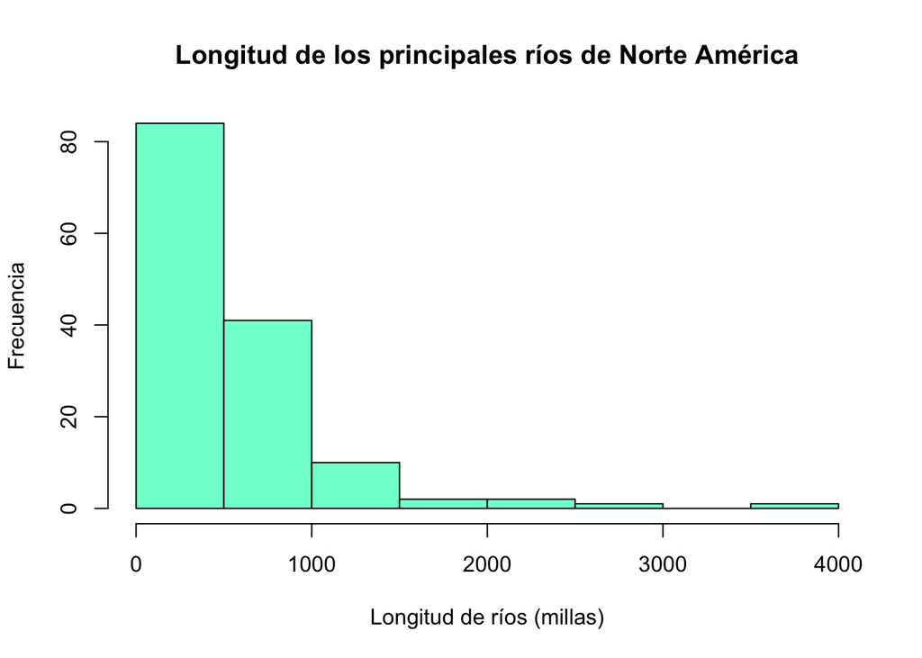

### **Ejercicio 5.** **Discusión**

Discute con tu compañeros que fue lo más difícil al programar tu base de datos y cuales fueron los errores más comunes.